# Algorithm to make city urban master plan

## Description

### Input data

Input - GeoJSON file with main objects, restrictions and areas for buildings The program must do next:

1. Plot boundaries – transmitted in GeoJSON format (FeatureCollection with Polygon).
2. Take into account restrictions on building density – percentage of the plot area allowed for development.
3. Take into account minimum distance between objects – for example, 10 meters between buildings.
4. Additional restrictions – presence of roads, forests, water bodies on which construction is prohibited (also transmitted in GeoJSON).

### Algorithm tasks

1. Divide the site into logical zones (e.g. residential buildings, parks, roads).
2. Place objects (buildings, roads, green areas) taking into account the specified restrictions, excluding construction in prohibited zones (roads, forests, water bodies).
3. Generate an image of the site plan.
4. Create a GeoJSON file with the coordinates of the placed objects.

```
The autoreload extension is already loaded. To reload it, use:
  %reload_ext autoreload
```

```
output\geo_data_output
```

```
                                            geometry            name  \
0  POLYGON ((37.6173 55.7558, 37.6179 55.7565, 37...  Зона застройки
1  POLYGON ((37.618 55.756, 37.6185 55.7565, 37.6...     Лесная зона
2      LINESTRING (37.6175 55.7555, 37.6185 55.7555)          Дорога

  restriction
0         NaN
1    no_build
2    no_build
```

Before - project coordinates to local meters system for simplifying further analyze. After analyze and design the result would be exported to original coordinate system

```
                                            geometry            name  \
0  POLYGON ((413224.138 6179766.954, 413263.344 6...  Зона застройки
1  POLYGON ((413268.509 6179788.334, 413300.995 6...     Лесная зона
2  LINESTRING (413236.022 6179733.319, 413298.777...          Дорога

  restriction
0         NaN
1    no_build
2    no_build
```

```
Local bounds: [  0.           0.         107.1250254  112.03178761]
```

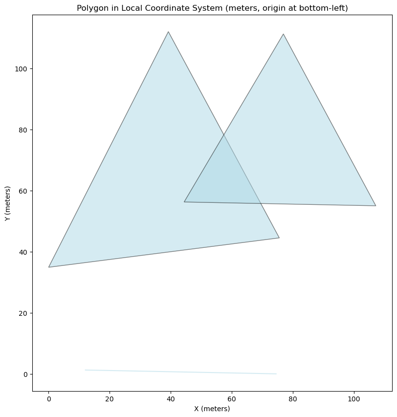

```
Back to WGS84 bounds: [37.6173 55.7555 37.619  55.7565]
```

```
                                            geometry            name  \
0  POLYGON ((0 34.886, 39.206 112.032, 75.526 44....  Зона застройки
1  POLYGON ((44.372 56.266, 76.858 111.281, 107.1...     Лесная зона
2  POLYGON ((74.679 2, 74.875 1.986, 75.068 1.953...          Дорога

  restriction
0         NaN
1    no_build
2    no_build
```

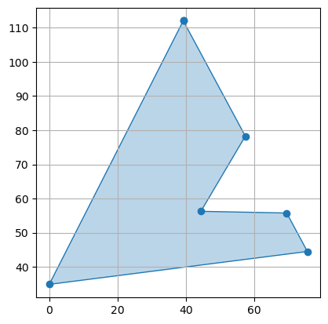

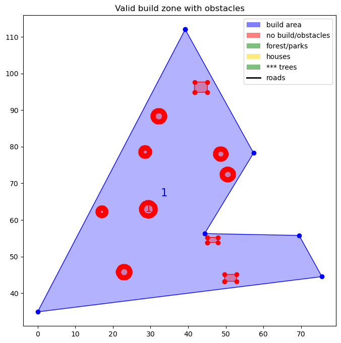

```
(<Figure size 800x800 with 1 Axes>, <Axes: >)
```

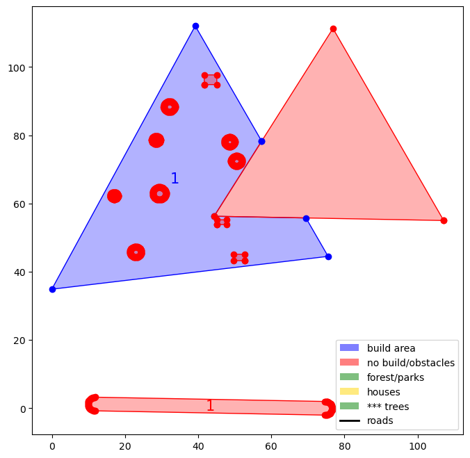

Separate territory into zones for buildings, roads and park For separation Voronoi diagram would be used

```
max_build_area:978.05
required_radius:3.95
house_zone_area:49.13
n_houses_max:20
```

[output not shown]

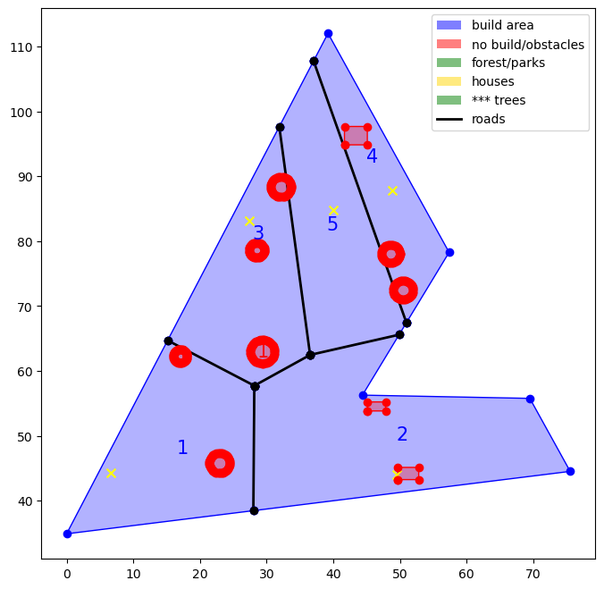

```
[<LINESTRING (15.151 64.699, 28.152 57.718)>, <LINESTRING (28.152 57.718, 28.009 38.456)>, <LINESTRING (28.152 57.718, 36.519 62.466)>, <LINESTRING (36.519 62.466, 49.871 65.579)>, <LINESTRING (31.898 97.652, 36.519 62.466)>, <LINESTRING (50.964 67.431, 37.042 107.775)>]
```

```
(<Figure size 800x800 with 1 Axes>, <Axes: >)
```

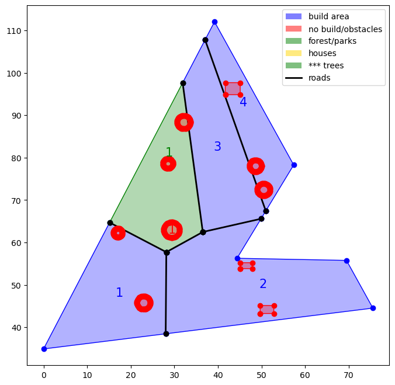

```
area for buildings except parks: 2445.1187458073728,
is it enough (>978.0474983229492)?: True
```

now lest add some syntetic obstacles in the middle of the road and try to optimize the path to go around it + take into account other obstacles we had before

```
road 0: (15.150824168627588, 64.69853474328349) - (28.152355804211684, 57.717899237853786)
road constructed in 3 parts
road 1: (28.152355804211684, 57.717899237853786) - (28.00879379398925, 38.45605638539723)
road constructed in 3 parts
road 2: (28.152355804211684, 57.717899237853786) - (36.51920834443528, 62.46580199052502)
road constructed in 2 parts
road 3: (36.51920834443528, 62.46580199052502) - (49.87089721461349, 65.57929547336421)
road constructed in 2 parts
road 4: (31.89793419961828, 97.65188158994803) - (36.51920834443528, 62.46580199052502)
road constructed in 3 parts
road 5: (50.96429335172382, 67.43095667053169) - (37.042323080617514, 107.77451354232576)
road constructed in 3 parts
```

```
(<Figure size 800x800 with 1 Axes>, <Axes: >)
```

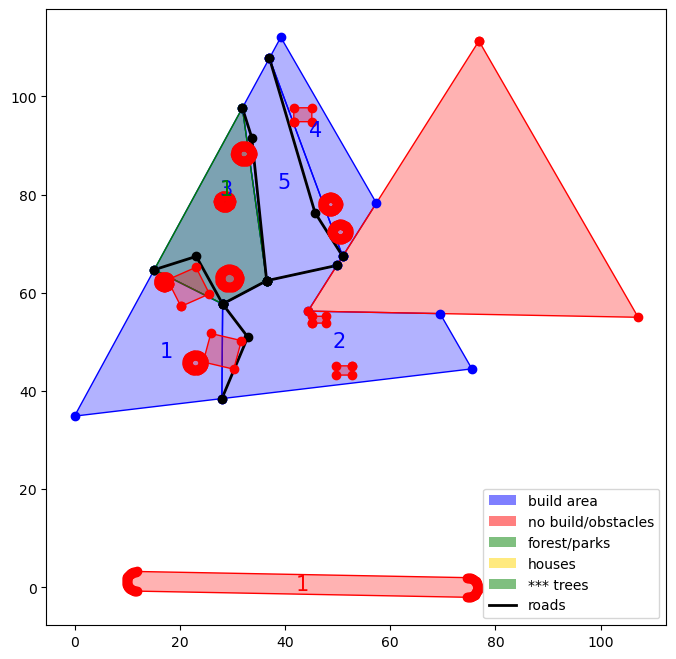

```
                                            geometry  \
0  POLYGON ((0 34.886, 39.206 112.032, 75.526 44....
1  POLYGON ((44.372 56.266, 76.858 111.281, 107.1...
2  POLYGON ((74.679 2, 74.875 1.986, 75.068 1.953...
0  MULTIPOLYGON (((51.956 72.467, 51.948 72.322, ...
0  POLYGON ((28.152 57.718, 28.009 38.456, 0 34.8...
1  POLYGON ((28.152 57.718, 36.519 62.466, 49.871...
2  POLYGON ((36.519 62.466, 28.152 57.718, 15.151...
3  POLYGON ((37.042 107.775, 39.206 112.032, 57.3...
4  POLYGON ((50.964 67.431, 49.871 65.579, 36.519...
0  POLYGON ((36.519 62.466, 28.152 57.718, 15.151...
0  LINESTRING (15.151 64.699, 23.136 67.417, 28.1...
1  LINESTRING (28.152 57.718, 32.928 50.993, 28.0...
2          LINESTRING (28.152 57.718, 36.519 62.466)
3          LINESTRING (36.519 62.466, 49.871 65.579)
```

[output cut: 24 more lines]

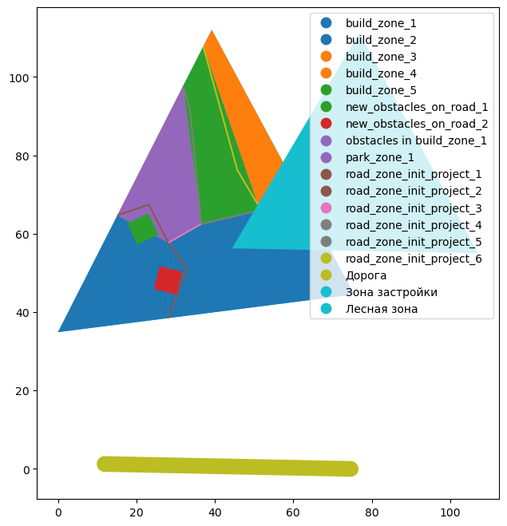

# Place objects into map - buildings, roads, green zones

taking into account restrictions

```
(<Figure size 800x800 with 1 Axes>, <Axes: >)
```

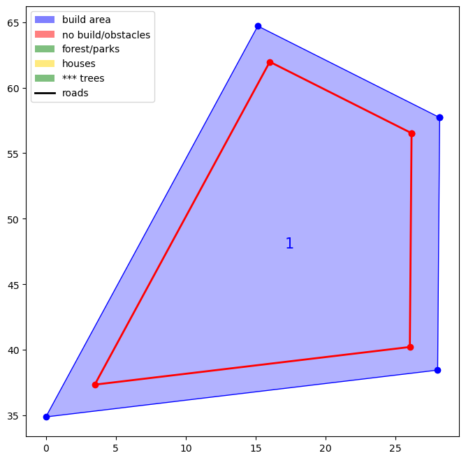

```
zone 0
poly_area:516.18
house radius:1.95
poly_build_area:206.47
center_zone_area:49.13
estimated number of centers: 5
estimated number of houses: 18
number of generated centers on grid: 4
Could only place 4 of 5 centers due to space/restrictions
Warning: Requested 20 centers, but max possible ~17
Could only place 0 of 20 centers due to space/restrictions

zone 1
poly_area:767.82
house radius:1.95
poly_build_area:307.13
center_zone_area:49.13
estimated number of centers: 7
estimated number of houses: 26
number of generated centers on grid: 12
select that are far from restrictions
Could only place 0 of 20 centers due to space/restrictions

zone 2
poly_area:450.50
house radius:1.95
poly_build_area:180.20
center_zone_area:49.13
estimated number of centers: 4
estimated number of houses: 16
number of generated centers on grid: 2
Could only place 2 of 4 centers due to space/restrictions
Warning: Requested 20 centers, but max possible ~15
number of generated centers on grid: 1
Could only place 1 of 20 centers due to space/restrictions

zone 3
poly_area:279.78
house radius:1.95
poly_build_area:111.91
center_zone_area:49.13
estimated number of centers: 3
estimated number of houses: 10
Could only place 0 of 3 centers due to space/restrictions
Warning: Requested 20 centers, but max possible ~10
Could only place 0 of 20 centers due to space/restrictions
Warning: Requested 430 centers, but max possible ~15
number of generated centers on grid: 2
Could only place 2 of 430 centers due to space/restrictions
```

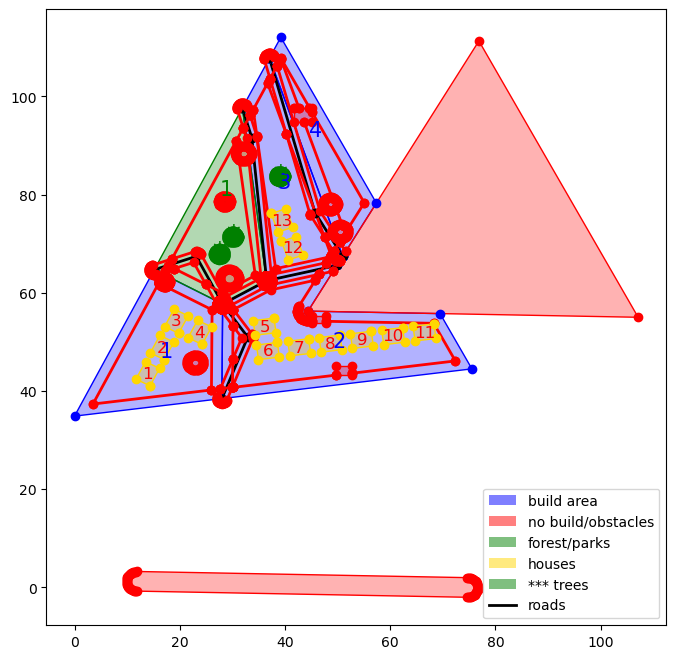

# Save and export results

```
Map saved to output\geo_data_output.png
```

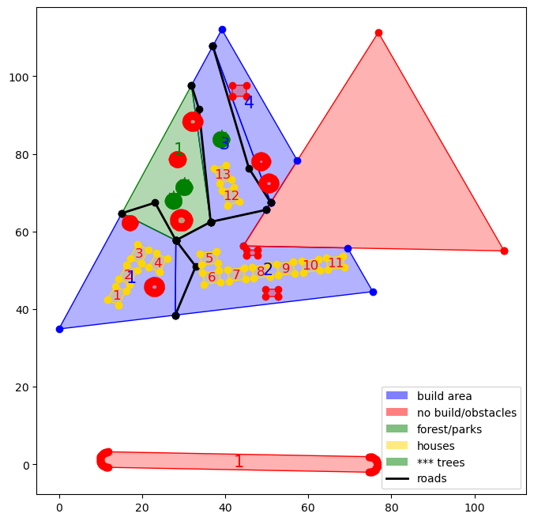

all coordinates are converted from local back to EPSG

```
                                             geometry  \
0   POLYGON ((37.6173 55.7558, 37.6179 55.7565, 37...
1   POLYGON ((37.618 55.756, 37.6185 55.7565, 37.6...
2   POLYGON ((37.6185 55.75552, 37.6185 55.75552, ...
0   MULTIPOLYGON (((37.61812 55.75615, 37.61812 55...
0   POLYGON ((37.61774 55.75601, 37.61775 55.75584...
1   POLYGON ((37.61774 55.75601, 37.61787 55.75605...
2   POLYGON ((37.61787 55.75605, 37.61774 55.75601...
3   POLYGON ((37.61787 55.75646, 37.6179 55.7565, ...
4   POLYGON ((37.6181 55.7561, 37.61808 55.75608, ...
0   POLYGON ((37.61787 55.75605, 37.61774 55.75601...
0   LINESTRING (37.61753 55.75607, 37.61766 55.756...
1   LINESTRING (37.61774 55.75601, 37.61782 55.755...
2   LINESTRING (37.61774 55.75601, 37.61787 55.75605)
3   LINESTRING (37.61787 55.75605, 37.61808 55.75608)
```

[output cut: 55 more lines]

```
Report saved to output\geo_data_output.html
```